# Project 3

Elijah Hawk

03/22/2020

This R Notebook is divided into multiple sections. Each section is divided in such a way to make reading through it as easy, clear, and concise as possible. :)

## Exploratory Data Analysis

### Creating new data out of existing data

```r
library(readr)
library(readxl)
library(ggplot2)
library(tidyverse)
library(dplyr)
library(magrittr)
library(cowplot)
library(caret)
library(lattice)
library(MASS)
library(pROC)
setwd("C:/Users/My Computer/Git/spotify-capstone")

spotifyMusic = as.data.frame(read_xlsx("hot_one_hundred_audio_features.xlsx"))

dim(spotifyMusic)
```

```
## [1] 28492    22
```

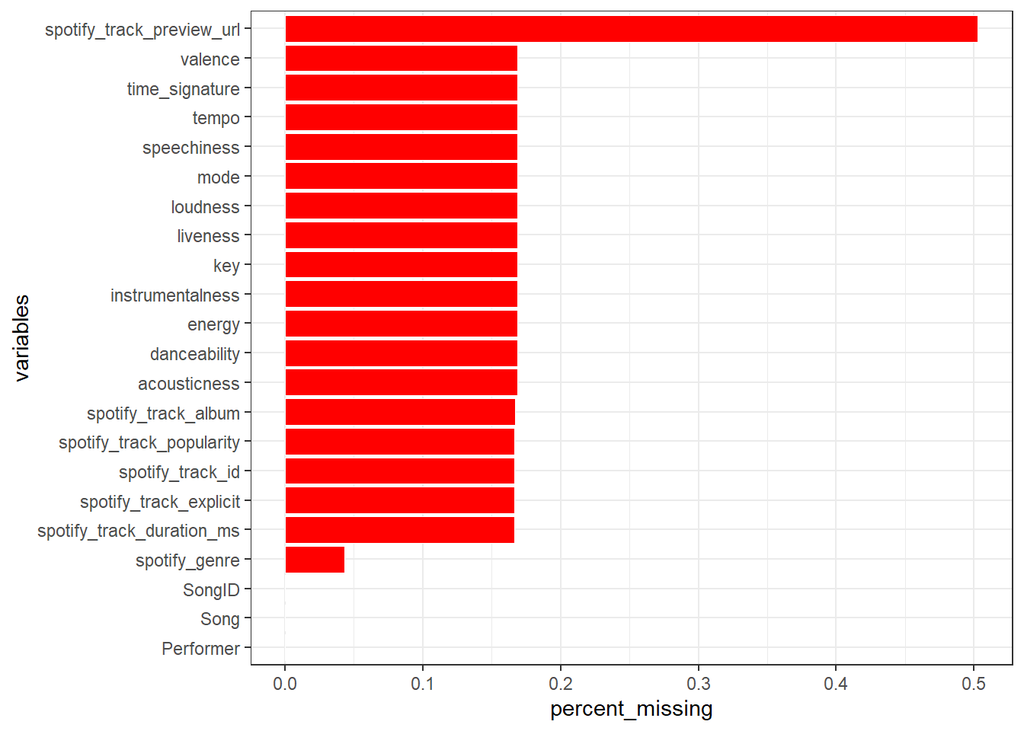

```r
#### Visualizing NAs ####
missing_data <- spotifyMusic %>% summarise_all(funs(sum(is.na(.))/n()))
missing_data <- gather(missing_data, key = "variables", value = "percent_missing")
ggplot(missing_data, aes(x = reorder(variables, percent_missing), y = percent_missing)) +
  geom_bar(stat = "identity", fill = "red", aes(color = I('white')), size = 0.3)+
  xlab('variables')+
  coord_flip()+
  theme_bw()
```

```r
spotifyMusic = na.omit(spotifyMusic)

dim(spotifyMusic)
```

```
## [1] 14049    22
```

```r
# drop unnecessary observations
spotifyMusic$SongID = NULL
spotifyMusic$Performer = NULL
spotifyMusic$Song = NULL
spotifyMusic$spotify_genre = NULL
spotifyMusic$spotify_track_id = NULL
spotifyMusic$spotify_track_preview_url = NULL
spotifyMusic$spotify_track_album = NULL

dim(spotifyMusic)
```

```
## [1] 14049    15
```

```r
#### generate new observations by setting thresholds for determining kinds of music ####
spotifyMusic$is_energetic = factor(ifelse(spotifyMusic$energy >=0.5, "1", "0"))
spotifyMusic$is_danceful = factor(ifelse(spotifyMusic$danceability >=0.5, "1", "0"))
spotifyMusic$is_speechy = factor(ifelse(spotifyMusic$speechiness >=0.5, "1", "0"))
spotifyMusic$is_acoustic = factor(ifelse(spotifyMusic$acousticness >=0.5, "1", "0"))
spotifyMusic$is_live = factor(ifelse(spotifyMusic$liveness >=0.5, "1", "0"))
spotifyMusic$is_positive = factor(ifelse(spotifyMusic$valence >=0.5, "1", "0"))
spotifyMusic$is_loud = factor(ifelse(spotifyMusic$loudness <=-11, "1", "0"))
spotifyMusic$is_popular = factor(ifelse(spotifyMusic$spotify_track_popularity >=50, "1", "0"))
```

## Split data into train and test sets

### Divide data into a 60/40 split

```r
#### Create test/train data sets using a 60/40 split ####
set.seed(99)
fullset <- createDataPartition(spotifyMusic$is_popular, p=0.60, list=FALSE)
# select 60% of data to train the models
trainset <- spotifyMusic[fullset,]
# select 40% of the data for testing
testset <- spotifyMusic[-fullset,]

dim(trainset)
```

```
## [1] 8430   23
```

```r
dim(testset)
```

```
## [1] 5619   23
```

## Visualize Data Using ggplot

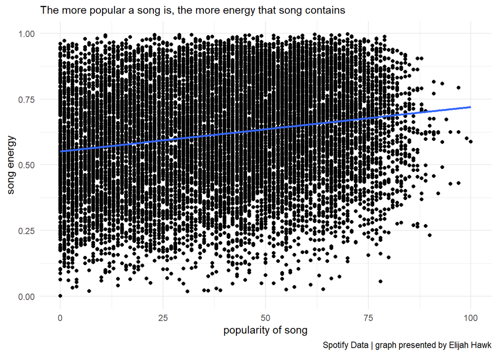

```r
#### Explore data through visualizations using ggplot ####

# popularity and energy
ggplot(spotifyMusic, aes(spotify_track_popularity, energy)) +
  geom_point() +
  geom_smooth(method = "lm", se = FALSE) +
  theme_minimal() +
  labs(x = "popularity of song",
       y = "song energy",
       subtitle = "The more popular a song is, the more energy that song contains",
       caption = "Spotify Data | graph presented by Elijah Hawk")
```

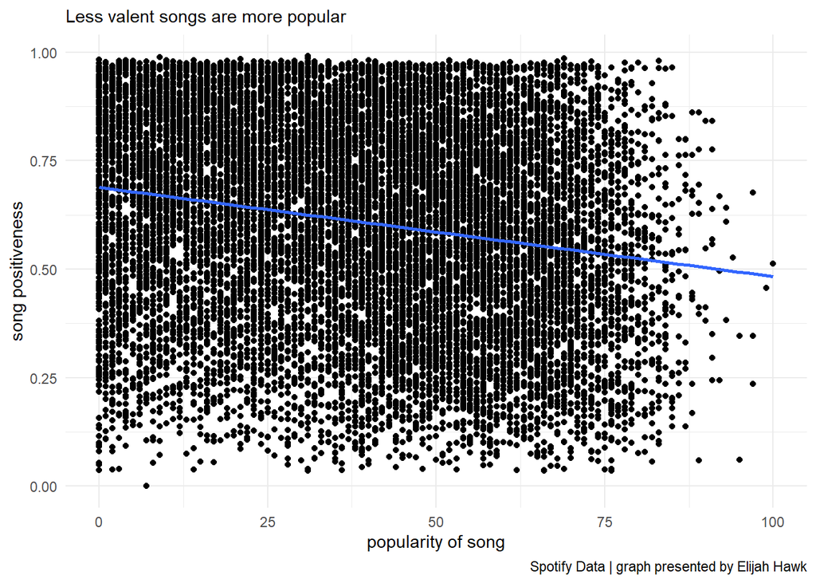

```r
# popularity and valence
ggplot(spotifyMusic, aes(spotify_track_popularity, valence)) +
  geom_point() +
  geom_smooth(method = "lm", se = FALSE) +
  theme_minimal() +
  labs(x = "popularity of song",
       y = "song positiveness",
       subtitle = "Less valent songs are more popular",
       caption = "Spotify Data | graph presented by Elijah Hawk")
```

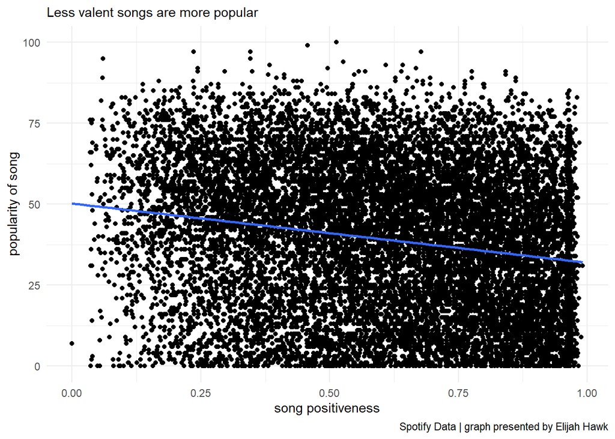

```r
# valence and popularity
ggplot(spotifyMusic, aes(valence, spotify_track_popularity)) +
  geom_point() +
  geom_smooth(method = "lm", se = FALSE) +
  theme_minimal() +
  labs(x = "song positiveness",
       y = "popularity of song",
       subtitle = "Less valent songs are more popular",
       caption = "Spotify Data | graph presented by Elijah Hawk")
```

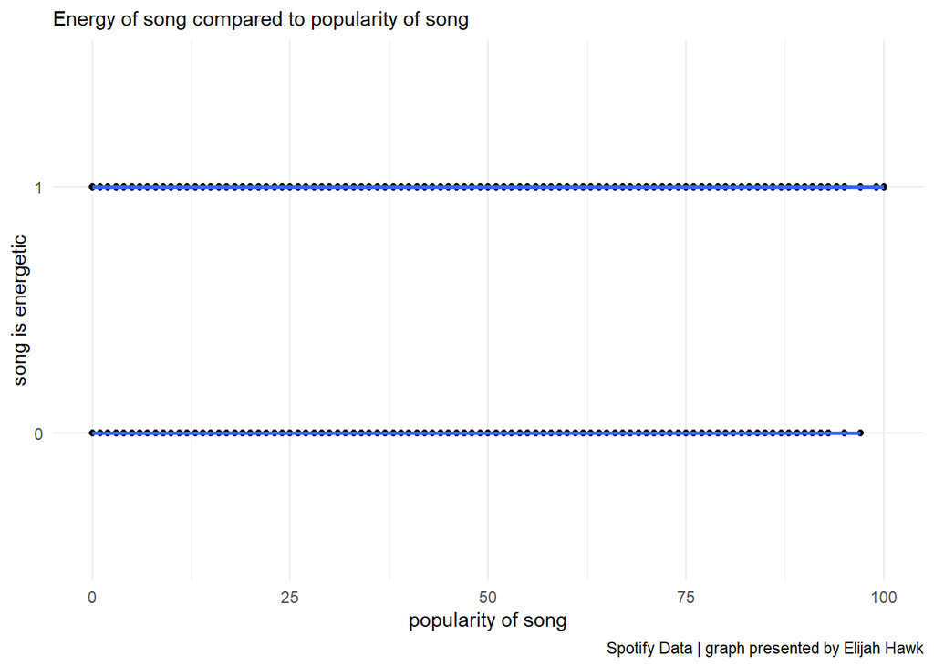

```r
# popularity and energetic songs
ggplot(spotifyMusic, aes(spotify_track_popularity, is_energetic)) +
  geom_point() +
  geom_smooth(method = "lm", se = FALSE) +
  theme_minimal() +
  labs(x = "popularity of song",
       y = "song is energetic",
       subtitle = "Energy of song compared to popularity of song",
       caption = "Spotify Data | graph presented by Elijah Hawk")
```

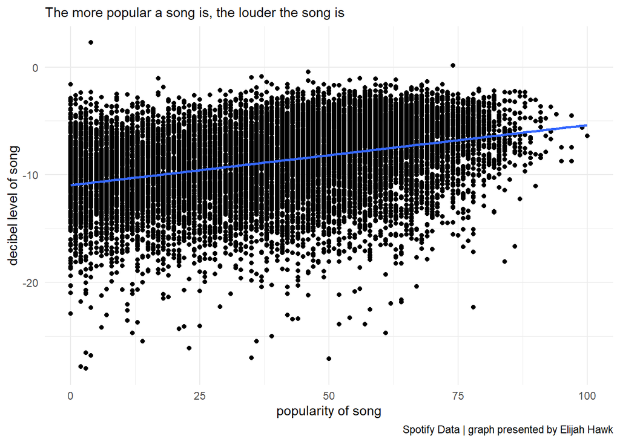

```r
# loudness and popularity
ggplot(spotifyMusic, aes(spotify_track_popularity, loudness)) +
  geom_point() +
  geom_smooth(method = "lm", se = FALSE) +
  theme_minimal() +
  labs(x = "popularity of song",
       y = "decibel level of song",
       subtitle = "The more popular a song is, the louder the song is",
       caption = "Spotify Data | graph presented by Elijah Hawk")
```

[figure not shown]

```r
# tempo and popularity
ggplot(spotifyMusic, aes(spotify_track_popularity, tempo)) +
  geom_point() +
  geom_smooth(method = "lm", se = FALSE) +
  theme_minimal() +
  labs(x = "song BPM",
       y = "popularity of song",
       subtitle = "The pace of the song does not determine whether a song will be popular or not",
       caption = "Spotify Data | graph presented by Elijah Hawk")
```

## Output statistical data about components of the dataset

```r
### Print out statistical summaries ####
summary(spotifyMusic$spotify_track_popularity)
```

```
##    Min. 1st Qu.  Median    Mean 3rd Qu.    Max.
##     0.0    20.0    40.0    39.1    57.0   100.0
```

```r
summary(spotifyMusic$loudness)
```

```
##    Min. 1st Qu.  Median    Mean 3rd Qu.    Max.
## -28.030 -11.136  -8.376  -8.790  -6.020   2.291
```

```r
summary(spotifyMusic$tempo)
```

```
##    Min. 1st Qu.  Median    Mean 3rd Qu.    Max.
##    0.00   99.45  119.38  120.39  136.21  233.43
```

```r
summary(spotifyMusic$valence)
```

```
##    Min. 1st Qu.  Median    Mean 3rd Qu.    Max.
##  0.0000  0.4240  0.6310  0.6084  0.8100  0.9910
```

```r
summary(spotifyMusic$acousticness)
```

```
##     Min.  1st Qu.   Median     Mean  3rd Qu.     Max.
## 5.70e-06 4.61e-02 2.01e-01 3.01e-01 5.29e-01 9.90e-01
```

```r
summary(spotifyMusic$danceability)
```

```
##    Min. 1st Qu.  Median    Mean 3rd Qu.    Max.
##  0.0000  0.4950  0.6060  0.5968  0.7060  0.9860
```

```r
summary(spotifyMusic$instrumentalness)
```

```
##      Min.   1st Qu.    Median      Mean   3rd Qu.      Max.
## 0.0000000 0.0000000 0.0000061 0.0374703 0.0006380 0.9820000
```

## Additional visualizations using bar charts, box plots, and violin charts

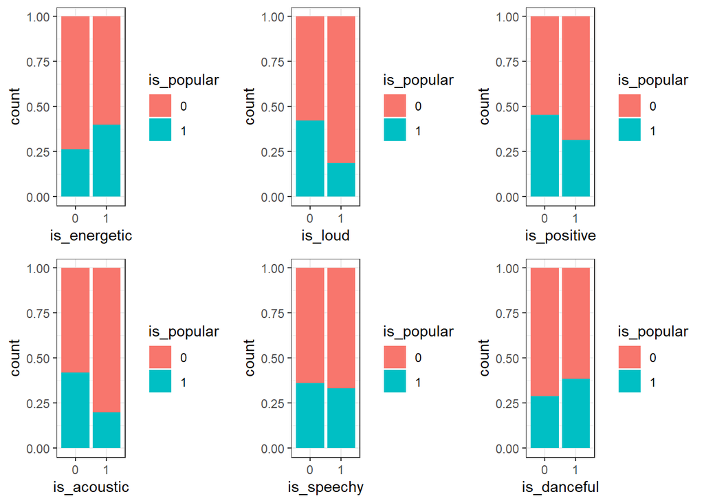

```r
# columns created can be visualized using bar charts
plot_grid(ggplot(spotifyMusic, aes(x=is_energetic,fill=is_popular))+ geom_bar(position = 'fill')+ theme_bw()+
            scale_x_discrete(labels = function(x) str_wrap(x, width = 10)),
          ggplot(spotifyMusic, aes(x=is_loud,fill=is_popular))+ geom_bar(position = 'fill')+theme_bw()+
            scale_x_discrete(labels = function(x) str_wrap(x, width = 10)),
          ggplot(spotifyMusic, aes(x=is_positive,fill=is_popular))+ geom_bar(position = 'fill')+theme_bw()+
            scale_x_discrete(labels = function(x) str_wrap(x, width = 10)),
          ggplot(spotifyMusic, aes(x=is_acoustic,fill=is_popular))+ geom_bar(position = 'fill')+theme_bw()+
            scale_x_discrete(labels = function(x) str_wrap(x, width = 10)),
          ggplot(spotifyMusic, aes(x=is_speechy,fill=is_popular))+ geom_bar(position = 'fill')+theme_bw()+
            scale_x_discrete(labels = function(x) str_wrap(x, width = 10)),
          ggplot(spotifyMusic, aes(x=is_danceful,fill=is_popular))+ geom_bar(position = 'fill')+theme_bw()+
            scale_x_discrete(labels = function(x) str_wrap(x, width = 10)),align = "h")
```

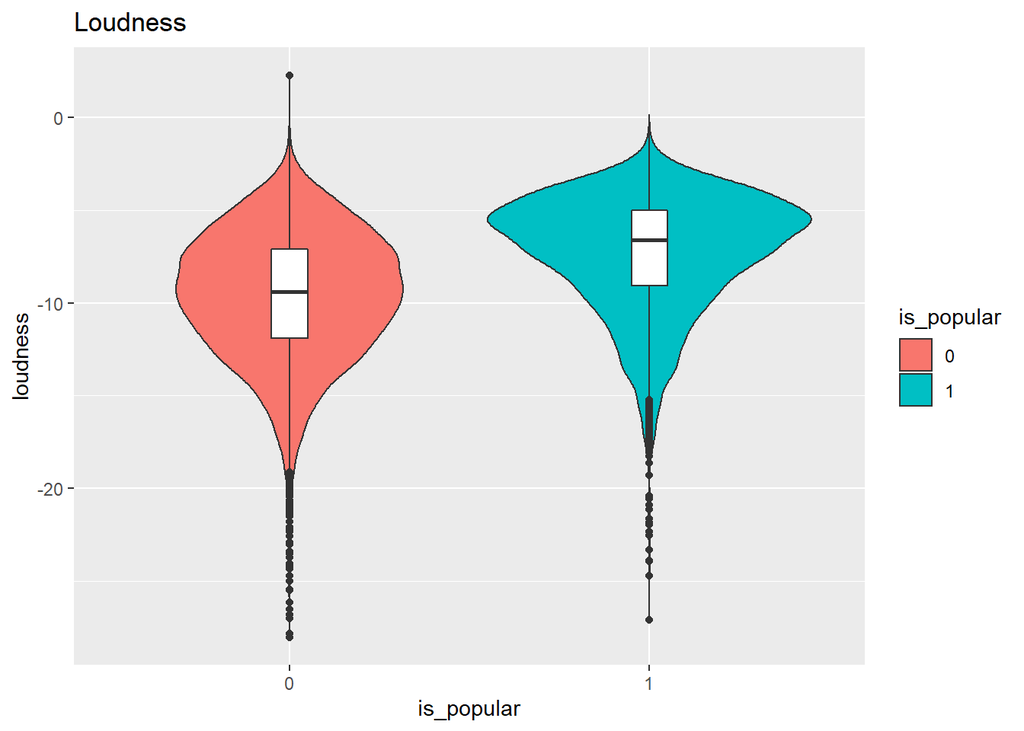

```r
# columns created can be visualized using violin charts
ggplot(spotifyMusic, aes(x=is_popular, y=loudness, fill=is_popular)) + geom_violin()+
  geom_boxplot(width=0.1, fill="white") + labs(title="Loudness")
```

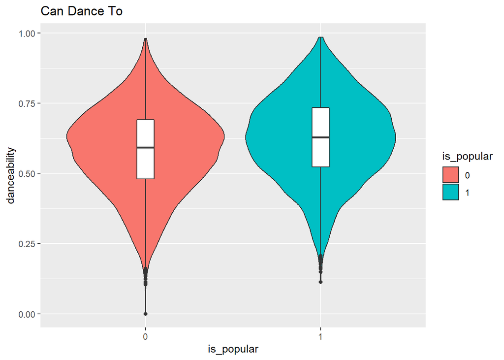

```r
ggplot(spotifyMusic, aes(x=is_popular, y=danceability, fill=is_popular)) + geom_violin()+
  geom_boxplot(width=0.1, fill="white") + labs(title="Can Dance To")
```

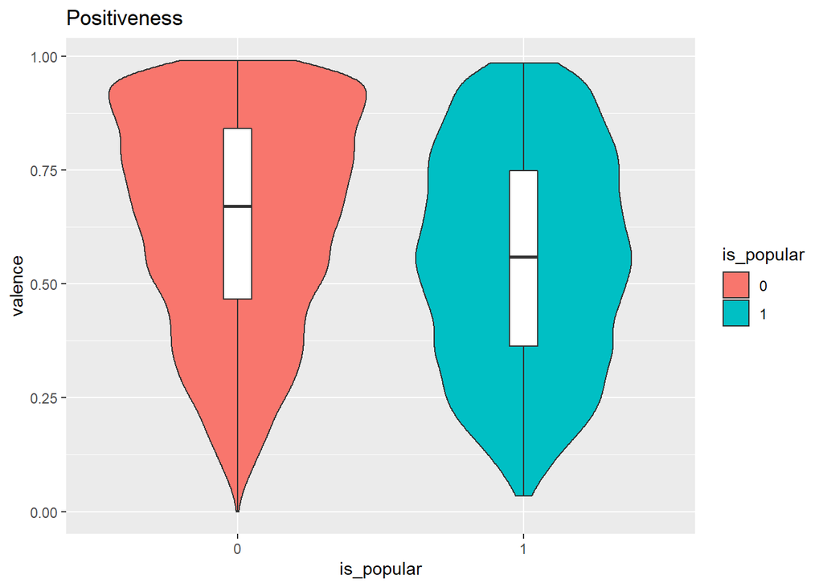

```r
ggplot(spotifyMusic, aes(x=is_popular, y=valence, fill=is_popular)) + geom_violin()+
  geom_boxplot(width=0.1, fill="white") + labs(title="Positiveness")
```

## OLS (Linear Regression)

```r
linearRegression01 = lm(spotify_track_popularity ~ .-is_popular-spotify_track_duration_ms, data = spotifyMusic)
summary(linearRegression01)
```

```
##
## Call:
## lm(formula = spotify_track_popularity ~ . - is_popular - spotify_track_duration_ms,
##     data = spotifyMusic)
##
## Residuals:
##     Min      1Q  Median      3Q     Max
## -72.903 -14.609  -0.226  13.906  73.093
##
## Coefficients:
##                              Estimate Std. Error t value Pr(>|t|)
## (Intercept)                 50.746341   2.708227  18.738  < 2e-16 ***
## spotify_track_explicitTRUE  10.304148   0.703165  14.654  < 2e-16 ***
## danceability                20.077079   1.899200  10.571  < 2e-16 ***
## energy                      -5.952637   1.782415  -3.340 0.000841 ***
## key                         -0.009822   0.045775  -0.215 0.830113
## loudness                     1.907563   0.090168  21.156  < 2e-16 ***
## mode                        -1.847644   0.376900  -4.902 9.58e-07 ***
## speechiness                  1.900613   2.764042   0.688 0.491703
## acousticness               -13.646722   1.282964 -10.637  < 2e-16 ***
## instrumentalness            -9.432953   1.107243  -8.519  < 2e-16 ***
## liveness                    -6.575296   1.573678  -4.178 2.95e-05 ***
## valence                    -24.540021   1.357711 -18.075  < 2e-16 ***
## tempo                        0.024790   0.006105   4.061 4.91e-05 ***
## time_signature               3.559175   0.530448   6.710 2.02e-11 ***
## is_energetic1               -0.802232   0.603575  -1.329 0.183825
## is_danceful1                 1.144837   0.584818   1.958 0.050297 .
## is_speechy1                 -5.683985   3.666759  -1.550 0.121131
## is_acoustic1                -0.806022   0.755904  -1.066 0.286306
## is_live1                     0.255274   1.071775   0.238 0.811746
## is_positive1                 0.024821   0.625850   0.040 0.968365
## is_loud1                     3.022105   0.599614   5.040 4.71e-07 ***
## ---
## Signif. codes:  0 '***' 0.001 '**' 0.01 '*' 0.05 '.' 0.1 ' ' 1
##
## Residual standard error: 19.09 on 14028 degrees of freedom
## Multiple R-squared:  0.2807, Adjusted R-squared:  0.2797
## F-statistic: 273.8 on 20 and 14028 DF,  p-value: < 2.2e-16
```

```r
linearRegression02 = lm(spotify_track_popularity ~ .-is_popular-spotify_track_duration_ms-time_signature, data = spotifyMusic)
summary(linearRegression02)
```

```
##
## Call:
## lm(formula = spotify_track_popularity ~ . - is_popular - spotify_track_duration_ms -
##     time_signature, data = spotifyMusic)
##
## Residuals:
##     Min      1Q  Median      3Q     Max
## -73.034 -14.610  -0.184  13.932  70.638
##
## Coefficients:
##                              Estimate Std. Error t value Pr(>|t|)
## (Intercept)                 63.566281   1.922370  33.067  < 2e-16 ***
## spotify_track_explicitTRUE  10.351880   0.704232  14.700  < 2e-16 ***
## danceability                20.843134   1.898737  10.977  < 2e-16 ***
## energy                      -5.081782   1.780470  -2.854  0.00432 **
## key                         -0.013322   0.045844  -0.291  0.77136
## loudness                     1.885820   0.090251  20.895  < 2e-16 ***
## mode                        -1.860224   0.377486  -4.928 8.41e-07 ***
## speechiness                  2.227247   2.767946   0.805  0.42103
## acousticness               -13.957312   1.284138 -10.869  < 2e-16 ***
## instrumentalness            -9.401874   1.108969  -8.478  < 2e-16 ***
## liveness                    -6.833791   1.575673  -4.337 1.45e-05 ***
## valence                    -24.584318   1.359823 -18.079  < 2e-16 ***
## tempo                        0.023844   0.006113   3.901 9.63e-05 ***
## is_energetic1               -0.658669   0.604141  -1.090  0.27562
## is_danceful1                 1.288652   0.585341   2.202  0.02771 *
## is_speechy1                 -5.796395   3.672469  -1.578  0.11451
## is_acoustic1                -0.816471   0.757088  -1.078  0.28086
## is_live1                     0.403709   1.073226   0.376  0.70680
## is_positive1                 0.090113   0.626755   0.144  0.88568
## is_loud1                     3.035457   0.600551   5.054 4.37e-07 ***
## ---
## Signif. codes:  0 '***' 0.001 '**' 0.01 '*' 0.05 '.' 0.1 ' ' 1
##
## Residual standard error: 19.12 on 14029 degrees of freedom
## Multiple R-squared:  0.2784, Adjusted R-squared:  0.2774
## F-statistic: 284.9 on 19 and 14029 DF,  p-value: < 2.2e-16
```

Linear regression is not a good model to use because of the fact that there is so much variation in the data. Note that the Adjusted R-squared value is only 0.2774, further explaining that while there are some song features that can explain the popularity of a song, a variety of song types/genres have the potential to be popular.

## Supervised Machine Learning Techniques

### 10-fold Cross-Validation

Using 10-fold cross-validation and analyze the following models: LDA, tree, KNN, Bayesian GLM, SVM, Random Forest, and XGBoosting. To make sure we have the same result, let’s have the same random procedure: set.seed(99)

```r
control = trainControl(method="cv", number=10)
metric = "Accuracy"

# Linear Discriminant Analysis (LDA)
set.seed(99)
fit.lda = train(as.factor(is_popular)~., data=trainset, method="lda", metric=metric, trControl=control)

# Classfication and Regression Trees (CART)
set.seed(99)
fit.cart = train(as.factor(is_popular)~., data=trainset, method="rpart", metric=metric, trControl=control)

# K-Nearest Neighbors (KNN)
set.seed(99)
fit.knn = train(as.factor(is_popular)~., data=trainset, method="knn", metric=metric, trControl=control)

# Bayesian Generalized Linear Model
set.seed(99)
fit.logi = train(as.factor(is_popular)~., data=trainset, method="bayesglm", metric=metric, trControl=control)

# Support Vector Machines (SVM) --> a long long time
set.seed(99)
fit.svm = train(as.factor(is_popular)~., data=trainset, method="svmRadial", metric=metric, trControl=control)

# Random Forest
set.seed(99)
fit.rf = train(as.factor(is_popular)~., data=trainset, method="rf", metric=metric, trControl=control)

# Gradient Boosting Machines/XGBoost
set.seed(99)
fit.xgb = train(as.factor(is_popular)~., data=trainset, method="xgbLinear", metric=metric, trControl=control)

# Summarize the Best Model
# List the mean of accuracy and kappa, identify the best model to predict the whether a song is popular or not.
# Select Best Model
# summarize accuracy of models
results = resamples(list(lda=fit.lda, cart=fit.cart, knn=fit.knn, logi=fit.logi, svm=fit.svm, rf=fit.rf, xgb=fit.xgb))
summary(results)
```

```
##
## Call:
## summary.resamples(object = results)
##
## Models: lda, cart, knn, logi, svm, rf, xgb
## Number of resamples: 10
##
## Accuracy
##           Min.   1st Qu.    Median      Mean   3rd Qu.      Max. NA's
## lda  0.9561091 0.9635231 0.9655991 0.9653618 0.9685647 0.9703791    0
## cart 1.0000000 1.0000000 1.0000000 1.0000000 1.0000000 1.0000000    0
## knn  0.6381969 0.6472874 0.6631079 0.6588358 0.6685448 0.6737841    0
## logi 1.0000000 1.0000000 1.0000000 1.0000000 1.0000000 1.0000000    0
## svm  0.9703440 0.9744726 0.9804270 0.9784096 0.9810202 0.9893238    0
## rf   1.0000000 1.0000000 1.0000000 1.0000000 1.0000000 1.0000000    0
## xgb  1.0000000 1.0000000 1.0000000 1.0000000 1.0000000 1.0000000    0
##
## Kappa
##           Min.   1st Qu.    Median      Mean   3rd Qu.      Max. NA's
## lda  0.9070222 0.9225263 0.9267108 0.9262563 0.9328681 0.9367781    0
## cart 1.0000000 1.0000000 1.0000000 1.0000000 1.0000000 1.0000000    0
## knn  0.1795346 0.2038772 0.2354314 0.2291723 0.2531250 0.2713778    0
## logi 1.0000000 1.0000000 1.0000000 1.0000000 1.0000000 1.0000000    0
## svm  0.9353660 0.9445065 0.9575245 0.9531210 0.9588419 0.9769307    0
## rf   1.0000000 1.0000000 1.0000000 1.0000000 1.0000000 1.0000000    0
## xgb  1.0000000 1.0000000 1.0000000 1.0000000 1.0000000 1.0000000    0
```

## Logistic Regression

### Finding the best model to use

```r
logisticRegression01 = glm(is_popular ~ ., data = trainset, family = "binomial")
summary(logisticRegression01)
```

```
##
## Call:
## glm(formula = is_popular ~ ., family = "binomial", data = trainset)
##
## Deviance Residuals:
##        Min          1Q      Median          3Q         Max
## -3.934e-04  -2.000e-08  -2.000e-08   2.000e-08   4.315e-04
##
## Coefficients:
##                              Estimate Std. Error z value Pr(>|z|)
## (Intercept)                -1.705e+03  2.203e+04  -0.077    0.938
## spotify_track_explicitTRUE  3.837e-02  1.004e+03   0.000    1.000
## spotify_track_duration_ms  -3.150e-06  4.342e-03  -0.001    0.999
## spotify_track_popularity    3.440e+01  4.324e+02   0.080    0.937
## danceability                2.812e+00  2.680e+03   0.001    0.999
## energy                      7.521e-01  2.364e+03   0.000    1.000
## key                         2.010e-02  6.453e+01   0.000    1.000
## loudness                   -7.483e-03  1.340e+02   0.000    1.000
## mode                        5.324e-02  5.309e+02   0.000    1.000
## speechiness                -1.863e+00  3.718e+03  -0.001    1.000
## acousticness                5.339e-01  1.794e+03   0.000    1.000
## instrumentalness           -5.264e-01  1.673e+03   0.000    1.000
## liveness                    9.079e-01  2.118e+03   0.000    1.000
## valence                    -8.437e-02  2.232e+03   0.000    1.000
## tempo                       4.288e-03  8.410e+00   0.001    1.000
## time_signature              1.820e-01  1.196e+03   0.000    1.000
## is_energetic1              -7.138e-01  8.598e+02  -0.001    0.999
## is_danceful1               -5.914e-01  8.887e+02  -0.001    0.999
## is_speechy1                -9.590e+01  2.158e+05   0.000    1.000
## is_acoustic1               -1.773e-01  1.049e+03   0.000    1.000
## is_live1                   -4.829e-01  1.456e+03   0.000    1.000
## is_positive1                9.349e-02  9.562e+02   0.000    1.000
## is_loud1                   -5.638e-01  9.867e+02  -0.001    1.000
##
## (Dispersion parameter for binomial family taken to be 1)
##
##     Null deviance: 1.1026e+04  on 8429  degrees of freedom
## Residual deviance: 1.5796e-05  on 8407  degrees of freedom
## AIC: 46
##
## Number of Fisher Scoring iterations: 25
```

```r
# AIC: 46

logisticRegression02 = glm(is_popular ~ .-spotify_track_popularity, data = trainset, family = "binomial")
summary(logisticRegression02)
```

```
##
## Call:
## glm(formula = is_popular ~ . - spotify_track_popularity, family = "binomial",
##     data = trainset)
##
## Deviance Residuals:
##     Min       1Q   Median       3Q      Max
## -2.3444  -0.8317  -0.5581   0.9973   3.0848
##
## Coefficients:
##                              Estimate Std. Error z value Pr(>|z|)
## (Intercept)                -4.220e-01  5.046e-01  -0.836 0.403013
## spotify_track_explicitTRUE  1.139e+00  1.162e-01   9.798  < 2e-16 ***
## spotify_track_duration_ms   1.563e-06  4.099e-07   3.814 0.000137 ***
## danceability                1.374e+00  3.056e-01   4.495 6.96e-06 ***
## energy                     -9.181e-01  2.780e-01  -3.302 0.000959 ***
## key                         1.427e-03  7.257e-03   0.197 0.844147
## loudness                    2.380e-01  1.497e-02  15.904  < 2e-16 ***
## mode                       -7.812e-02  5.892e-02  -1.326 0.184827
## speechiness                 4.928e-01  4.346e-01   1.134 0.256834
## acousticness               -1.043e+00  2.052e-01  -5.085 3.68e-07 ***
## instrumentalness           -7.676e-01  2.131e-01  -3.602 0.000316 ***
## liveness                   -7.932e-01  2.537e-01  -3.126 0.001771 **
## valence                    -1.319e+00  2.181e-01  -6.050 1.45e-09 ***
## tempo                       3.219e-03  9.870e-04   3.261 0.001109 **
## time_signature              5.179e-01  1.047e-01   4.947 7.54e-07 ***
## is_energetic1              -1.077e-01  9.635e-02  -1.117 0.263879
## is_danceful1                1.832e-01  9.422e-02   1.945 0.051815 .
## is_speechy1                 8.420e-02  6.006e-01   0.140 0.888499
## is_acoustic1                6.030e-02  1.210e-01   0.499 0.618118
## is_live1                   -3.216e-03  1.784e-01  -0.018 0.985618
## is_positive1               -2.680e-01  9.877e-02  -2.714 0.006656 **
## is_loud1                    4.404e-01  9.967e-02   4.419 9.91e-06 ***
## ---
## Signif. codes:  0 '***' 0.001 '**' 0.01 '*' 0.05 '.' 0.1 ' ' 1
##
## (Dispersion parameter for binomial family taken to be 1)
##
##     Null deviance: 11026.0  on 8429  degrees of freedom
## Residual deviance:  9193.8  on 8408  degrees of freedom
## AIC: 9237.8
##
## Number of Fisher Scoring iterations: 4
```

```r
# AIC: 9237.8
# Previous model is better due to lower AIC

logisticRegression03 = glm(is_popular ~ .-spotify_track_popularity-spotify_track_duration_ms, data = trainset, family = "binomial")
summary(logisticRegression03)
```

```
##
## Call:
## glm(formula = is_popular ~ . - spotify_track_popularity - spotify_track_duration_ms,
##     family = "binomial", data = trainset)
##
## Deviance Residuals:
##     Min       1Q   Median       3Q      Max
## -2.3180  -0.8303  -0.5673   0.9983   3.0645
##
## Coefficients:
##                              Estimate Std. Error z value Pr(>|z|)
## (Intercept)                -0.0875884  0.4954958  -0.177 0.859690
## spotify_track_explicitTRUE  1.1226779  0.1161116   9.669  < 2e-16 ***
## danceability                1.4763193  0.3043507   4.851 1.23e-06 ***
## energy                     -0.8409668  0.2768572  -3.038 0.002385 **
## key                         0.0009861  0.0072513   0.136 0.891828
## loudness                    0.2313450  0.0148249  15.605  < 2e-16 ***
## mode                       -0.0992647  0.0586823  -1.692 0.090729 .
## speechiness                 0.4620686  0.4345185   1.063 0.287599
## acousticness               -1.1404188  0.2032680  -5.610 2.02e-08 ***
## instrumentalness           -0.7641768  0.2116737  -3.610 0.000306 ***
## liveness                   -0.8123314  0.2534678  -3.205 0.001351 **
## valence                    -1.4641809  0.2144917  -6.826 8.71e-12 ***
## tempo                       0.0031904  0.0009862   3.235 0.001217 **
## time_signature              0.5163198  0.1040787   4.961 7.02e-07 ***
## is_energetic1              -0.1016337  0.0962385  -1.056 0.290940
## is_danceful1                0.1766806  0.0940278   1.879 0.060241 .
## is_speechy1                 0.0691665  0.5996160   0.115 0.908167
## is_acoustic1                0.0600110  0.1206585   0.497 0.618933
## is_live1                    0.0100723  0.1780829   0.057 0.954896
## is_positive1               -0.2654462  0.0986933  -2.690 0.007154 **
## is_loud1                    0.4334845  0.0994999   4.357 1.32e-05 ***
## ---
## Signif. codes:  0 '***' 0.001 '**' 0.01 '*' 0.05 '.' 0.1 ' ' 1
##
## (Dispersion parameter for binomial family taken to be 1)
##
##     Null deviance: 11026.0  on 8429  degrees of freedom
## Residual deviance:  9210.1  on 8409  degrees of freedom
## AIC: 9252.1
##
## Number of Fisher Scoring iterations: 4
```

```r
# AIC: 9252.1
# Third model is really bad after taking out the popularity observations

# Used the first regression which includes an exact measure of how popular a song is
# Note that other regressions which remove this aspect return a much higher AIC
logisticRegression04 = stepAIC(logisticRegression01, direction="both")
```

```
## Start:  AIC=46
## is_popular ~ spotify_track_explicit + spotify_track_duration_ms +
##     spotify_track_popularity + danceability + energy + key +
##     loudness + mode + speechiness + acousticness + instrumentalness +
##     liveness + valence + tempo + time_signature + is_energetic +
##     is_danceful + is_speechy + is_acoustic + is_live + is_positive +
##     is_loud
##
##                             Df Deviance    AIC
## - danceability               1      0.0   44.0
## - is_energetic               1      0.0   44.0
## - is_loud                    1      0.0   44.0
## - is_danceful                1      0.0   44.0
## - spotify_track_duration_ms  1      0.0   44.0
## - energy                     1      0.0   44.0
## - speechiness                1      0.0   44.0
## - liveness                   1      0.0   44.0
## - tempo                      1      0.0   44.0
## - is_acoustic                1      0.0   44.0
## - time_signature             1      0.0   44.0
## - instrumentalness           1      0.0   44.0
## - acousticness               1      0.0   44.0
## - key                        1      0.0   44.0
## - is_live                    1      0.0   44.0
## - mode                       1      0.0   44.0
## - valence                    1      0.0   44.0
## - is_positive                1      0.0   44.0
## - loudness                   1      0.0   44.0
## - spotify_track_explicit     1      0.0   44.0
## - is_speechy                 1      0.0   44.0
## <none>                              0.0   46.0
## - spotify_track_popularity   1   9193.8 9237.8
##
## Step:  AIC=44
## is_popular ~ spotify_track_explicit + spotify_track_duration_ms +
##     spotify_track_popularity + energy + key + loudness + mode +
##     speechiness + acousticness + instrumentalness + liveness +
##     valence + tempo + time_signature + is_energetic + is_danceful +
##     is_speechy + is_acoustic + is_live + is_positive + is_loud
##
```

[output cut: 613 more lines]

```
## + mode                       1        0     6
## + acousticness               1        0     6
## + liveness                   1        0     6
## + is_speechy                 1        0     6
## + instrumentalness           1        0     6
## + key                        1        0     6
## + is_danceful                1        0     6
## + is_positive                1        0     6
## + time_signature             1        0     6
## + speechiness                1        0     6
## + energy                     1        0     6
## + valence                    1        0     6
## + danceability               1        0     6
## + is_energetic               1        0     6
## - spotify_track_popularity   1    11026 11028
```

```r
summary(logisticRegression04)
```

```
##
## Call:
## glm(formula = is_popular ~ spotify_track_popularity, family = "binomial",
##     data = trainset)
##
## Deviance Residuals:
##        Min          1Q      Median          3Q         Max
## -2.561e-04  -2.100e-08  -2.100e-08   2.100e-08   2.462e-04
##
## Coefficients:
##                          Estimate Std. Error z value Pr(>|z|)
## (Intercept)              -1709.96   21479.39   -0.08    0.937
## spotify_track_popularity    34.55     433.97    0.08    0.937
##
## (Dispersion parameter for binomial family taken to be 1)
##
##     Null deviance: 1.1026e+04  on 8429  degrees of freedom
## Residual deviance: 1.5630e-05  on 8428  degrees of freedom
## AIC: 4
##
## Number of Fisher Scoring iterations: 25
```

```r
# Using step-wise AIC in both directions, we can get our AIC down to 4!
# AIC: 4
```